# Análise da Base de Dados Notas

André Rizzo

#### **Descrição das variáveis**

- school ⟶ Name of the school the student is enrolled in.
- school_setting ⟶ The location of the school.
- school_type ⟶ The type of school. Either public or non-public
- classroom ⟶ The type of classroom.
- teaching_method ⟶ Teaching methods: Either experimental or Standard.
- n_student ⟶ Number of students in the class.
- student_id ⟶ A unique ID for each student.
- gender ⟶ The gender of the students: male or female
- lunch ⟶ Whether a student qualifies for free/subsidized lunch or not
- pretest ⟶ The pretest score of the students out of 100
- posttest ⟶ The posttest scores of the students out of 100

#### **Exibir as primeiras 10 linhas do dataset**

| school | school_setting | school_type | classroom | teaching_method | n_student | student_id | gender | lunch | pretest | posttest |
| --- | --- | --- | --- | --- | --- | --- | --- | --- | --- | --- |
| ANKYI | Urban | Non-public | 6OL | Standard | 20 | 2FHT3 | Female | Does not qualify | 62 | 72 |
| ANKYI | Urban | Non-public | 6OL | Standard | 20 | 3JIVH | Female | Does not qualify | 66 | 79 |
| ANKYI | Urban | Non-public | 6OL | Standard | 20 | 3XOWE | Male | Does not qualify | 64 | 76 |
| ANKYI | Urban | Non-public | 6OL | Standard | 20 | 556O0 | Female | Does not qualify | 61 | 77 |
| ANKYI | Urban | Non-public | 6OL | Standard | 20 | 74LOE | Male | Does not qualify | 64 | 76 |
| ANKYI | Urban | Non-public | 6OL | Standard | 20 | 7YZO8 | Female | Does not qualify | 66 | 74 |
| ANKYI | Urban | Non-public | 6OL | Standard | 20 | 9KMZD | Male | Does not qualify | 63 | 75 |
| ANKYI | Urban | Non-public | 6OL | Standard | 20 | 9USQK | Female | Does not qualify | 63 | 72 |
| ANKYI | Urban | Non-public | 6OL | Standard | 20 | CS5QP | Male | Does not qualify | 64 | 77 |
| ANKYI | Urban | Non-public | 6OL | Standard | 20 | D6HT8 | Female | Does not qualify | 61 | 72 |

#### **Exibir as últimas 10 linhas do dataset**

| school | school_setting | school_type | classroom | teaching_method | n_student | student_id | gender | lunch | pretest | posttest |
| --- | --- | --- | --- | --- | --- | --- | --- | --- | --- | --- |
| ZOWMK | Urban | Public | ZBH | Standard | 30 | KPR1P | Male | Qualifies for reduced/free lunch | 40 | 46 |
| ZOWMK | Urban | Public | ZBH | Standard | 30 | Q6QZP | Male | Qualifies for reduced/free lunch | 41 | 50 |
| ZOWMK | Urban | Public | ZBH | Standard | 30 | Q8JXJ | Female | Qualifies for reduced/free lunch | 45 | 47 |
| ZOWMK | Urban | Public | ZBH | Standard | 30 | R805N | Male | Qualifies for reduced/free lunch | 38 | 51 |
| ZOWMK | Urban | Public | ZBH | Standard | 30 | S4I5S | Male | Qualifies for reduced/free lunch | 39 | 50 |
| ZOWMK | Urban | Public | ZBH | Standard | 30 | T8LSK | Female | Does not qualify | 39 | 55 |
| ZOWMK | Urban | Public | ZBH | Standard | 30 | VNP26 | Female | Qualifies for reduced/free lunch | 38 | 46 |
| ZOWMK | Urban | Public | ZBH | Standard | 30 | YDR1Z | Female | Qualifies for reduced/free lunch | 45 | 51 |
| ZOWMK | Urban | Public | ZBH | Standard | 30 | YUEIH | Male | Qualifies for reduced/free lunch | 46 | 53 |
| ZOWMK | Urban | Public | ZBH | Standard | 30 | ZVCQ8 | Male | Qualifies for reduced/free lunch | 41 | 48 |

#### **Criar base de treinamento e base de teste**

Utilizou-se 70% dos dados para base de treinamento e 30% para teste

#### **Verificar a estrutura do dataset**

```
## tibble [1,495 x 11] (S3: tbl_df/tbl/data.frame)
##  $ school         : chr [1:1495] "ANKYI" "ANKYI" "ANKYI" "ANKYI" ...
##  $ school_setting : chr [1:1495] "Urban" "Urban" "Urban" "Urban" ...
##  $ school_type    : chr [1:1495] "Non-public" "Non-public" "Non-public" "Non-public" ...
##  $ classroom      : chr [1:1495] "6OL" "6OL" "6OL" "6OL" ...
##  $ teaching_method: chr [1:1495] "Standard" "Standard" "Standard" "Standard" ...
##  $ n_student      : num [1:1495] 20 20 20 20 20 20 20 20 20 20 ...
##  $ student_id     : chr [1:1495] "2FHT3" "3JIVH" "74LOE" "7YZO8" ...
##  $ gender         : chr [1:1495] "Female" "Female" "Male" "Female" ...
##  $ lunch          : chr [1:1495] "Does not qualify" "Does not qualify" "Does not qualify" "Does not qualify" ...
##  $ pretest        : num [1:1495] 62 66 64 66 63 63 64 61 61 64 ...
##  $ posttest       : num [1:1495] 72 79 76 74 75 72 77 72 73 74 ...
```

##### *Análise*

- A base é composta por 11 variáveis.
- Cada variável possui 1495 observações.
- Entre as 11 variáveis temos:
  - 8 qualitativas
  - 3 quantitativas

#### **Análise numérica da base de treinamento**

```
## df_train
##
##  11  Variables      1495  Observations
## --------------------------------------------------------------------------------
## school
##        n  missing distinct
##     1495        0       23
##
## lowest : ANKYI CCAAW CIMBB CUQAM DNQDD, highest: VHDHF VKWQH VVTVA ZMNYA ZOWMK
## --------------------------------------------------------------------------------
## school_setting
##        n  missing distinct
##     1495        0        3
##
## Value         Rural Suburban    Urban
## Frequency       357      496      642
## Proportion    0.239    0.332    0.429
## --------------------------------------------------------------------------------
## school_type
##        n  missing distinct
##     1495        0        2
##
## Value      Non-public     Public
## Frequency         382       1113
## Proportion      0.256      0.744
## --------------------------------------------------------------------------------
## classroom
##        n  missing distinct
##     1495        0       97
##
## lowest : 05H 08N 0N7 18K 197, highest: YTB YUC ZBH ZDT ZNS
## --------------------------------------------------------------------------------
## teaching_method
##        n  missing distinct
##     1495        0        2
##
## Value      Experimental     Standard
## Frequency           524          971
## Proportion        0.351        0.649
## --------------------------------------------------------------------------------
```

[output cut: 39 more lines]

```
##        n  missing distinct     Info     Mean      Gmd      .05      .10
##     1495        0       67        1    54.89    15.48       33       37
##      .25      .50      .75      .90      .95
##       44       55       65       72       77
##
## lowest : 22 25 26 27 28, highest: 86 87 88 89 91
## --------------------------------------------------------------------------------
## posttest
##        n  missing distinct     Info     Mean      Gmd      .05      .10
##     1495        0       66        1    67.02       16     45.0     48.4
##      .25      .50      .75      .90      .95
##     56.0     68.0     77.0     85.0     91.0
##
## lowest :  32  34  37  38  39, highest:  96  97  98  99 100
## --------------------------------------------------------------------------------
```

##### *Comentários*

Uma análise preliminar indica que a variável student_id não trás nenhum tipo de informação significativa, além disso possui alta cardinalidade. Desta forma, optou-se pela remoção da variável de modo a não trazer prejuízos para o modelo.

#### **Removendo a variável student_id**

| school | school_setting | school_type | classroom | teaching_method | n_student | gender | lunch | pretest | posttest |
| --- | --- | --- | --- | --- | --- | --- | --- | --- | --- |
| ANKYI | Urban | Non-public | 6OL | Standard | 20 | Female | Does not qualify | 62 | 72 |
| ANKYI | Urban | Non-public | 6OL | Standard | 20 | Female | Does not qualify | 66 | 79 |
| ANKYI | Urban | Non-public | 6OL | Standard | 20 | Male | Does not qualify | 64 | 76 |
| ANKYI | Urban | Non-public | 6OL | Standard | 20 | Female | Does not qualify | 66 | 74 |
| ANKYI | Urban | Non-public | 6OL | Standard | 20 | Male | Does not qualify | 63 | 75 |
| ANKYI | Urban | Non-public | 6OL | Standard | 20 | Female | Does not qualify | 63 | 72 |
| ANKYI | Urban | Non-public | 6OL | Standard | 20 | Male | Does not qualify | 64 | 77 |
| ANKYI | Urban | Non-public | 6OL | Standard | 20 | Female | Does not qualify | 61 | 72 |
| ANKYI | Urban | Non-public | 6OL | Standard | 20 | Male | Does not qualify | 61 | 73 |
| ANKYI | Urban | Non-public | 6OL | Standard | 20 | Male | Does not qualify | 64 | 74 |

#### **Organizando as variáveis**

```
## [1] "Variáveis quantitativas:"
```

| vars_numericas |
| --- |
| n_student |
| pretest |
| posttest |

```
## [1] "Variáveis qualitativas:"
```

| vars_categoricas |
| --- |
| school |
| school_setting |
| school_type |
| classroom |
| teaching_method |
| gender |
| lunch |

#### **Análise gráfica das variáveis qualitativas**

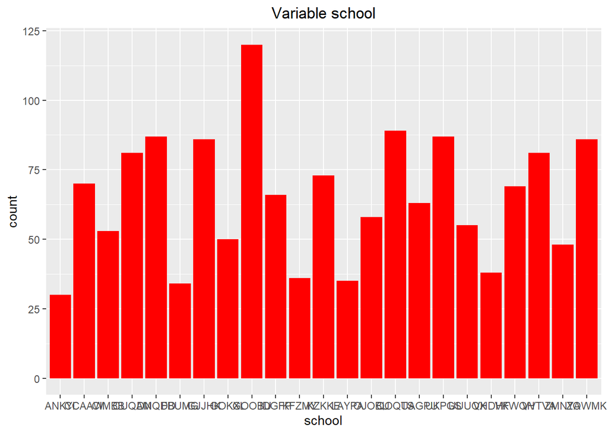

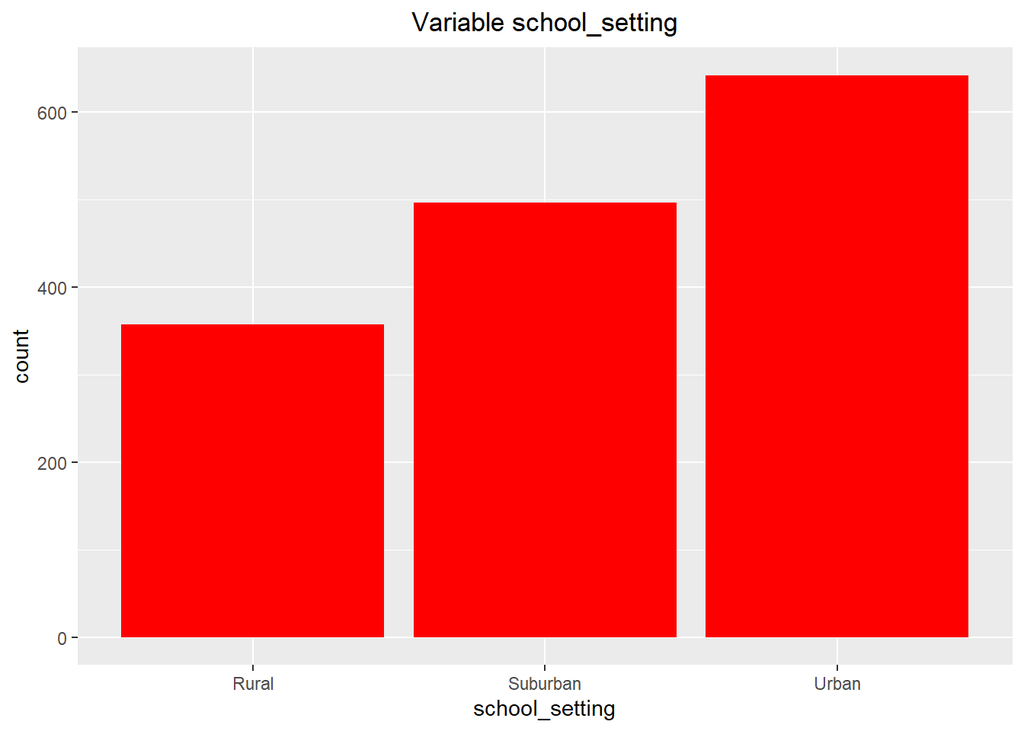

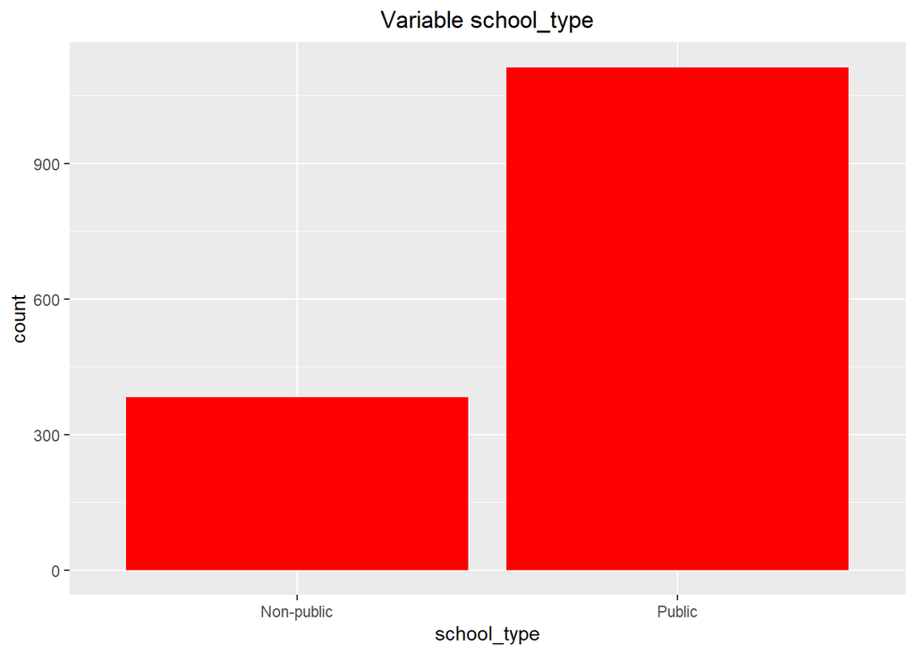

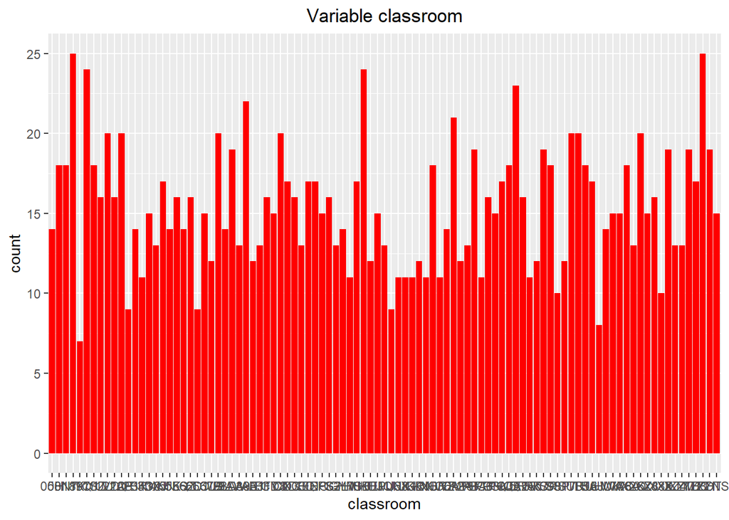

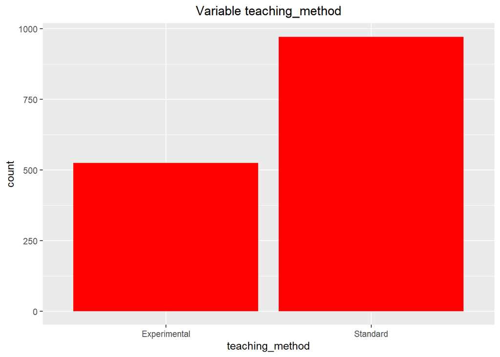

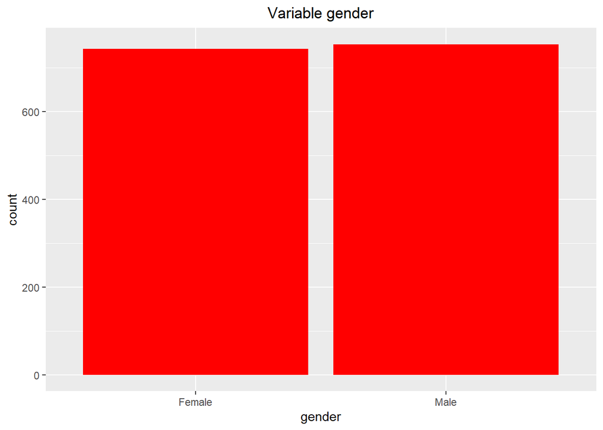

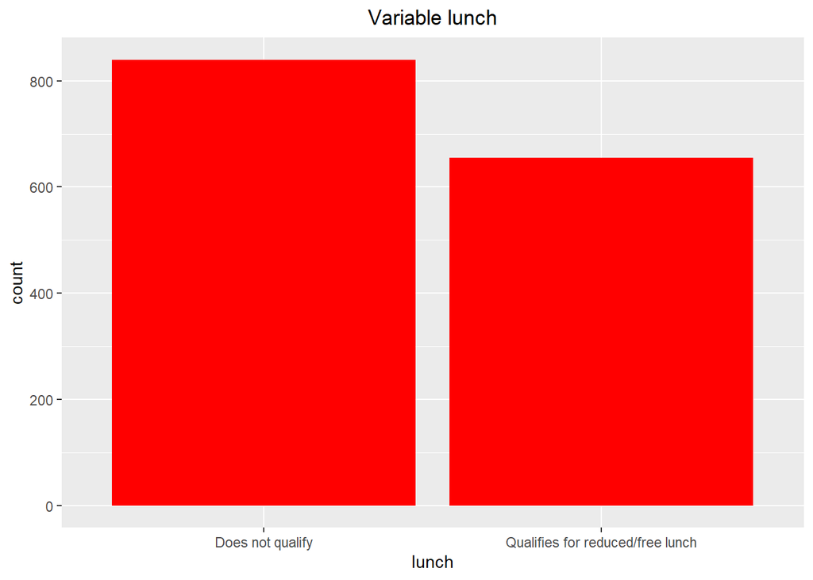

#### **Análise gráfica das variáveis quantitativas**

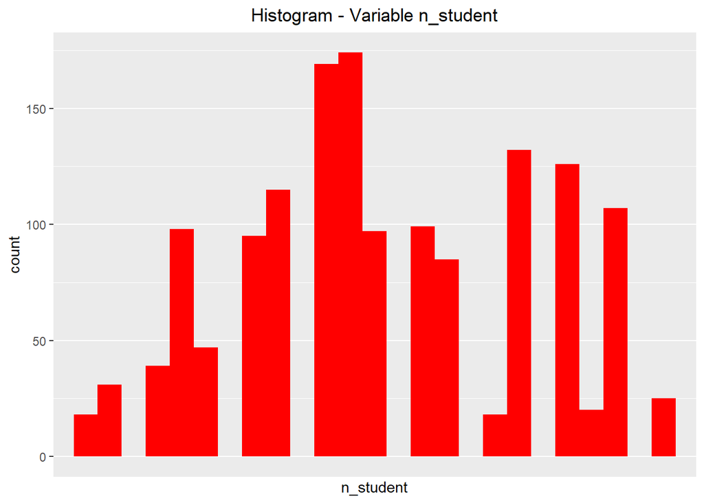

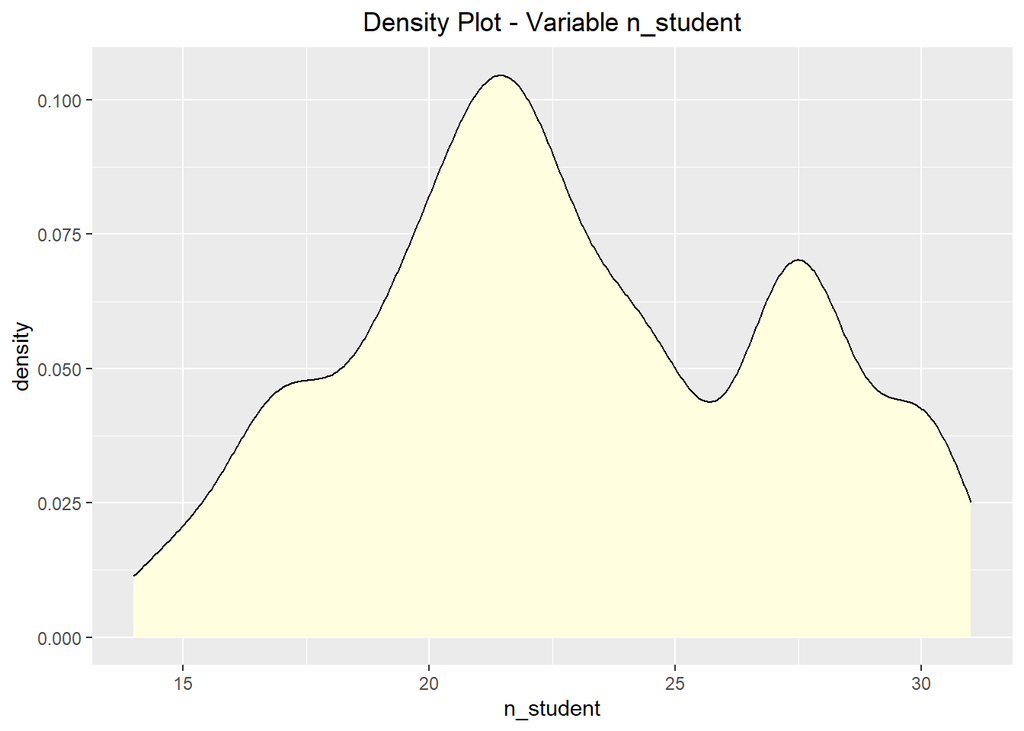

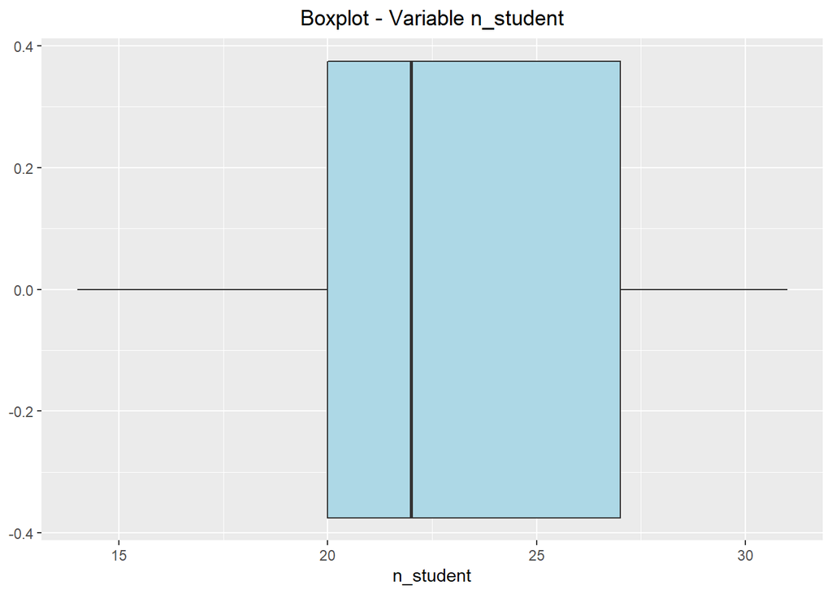

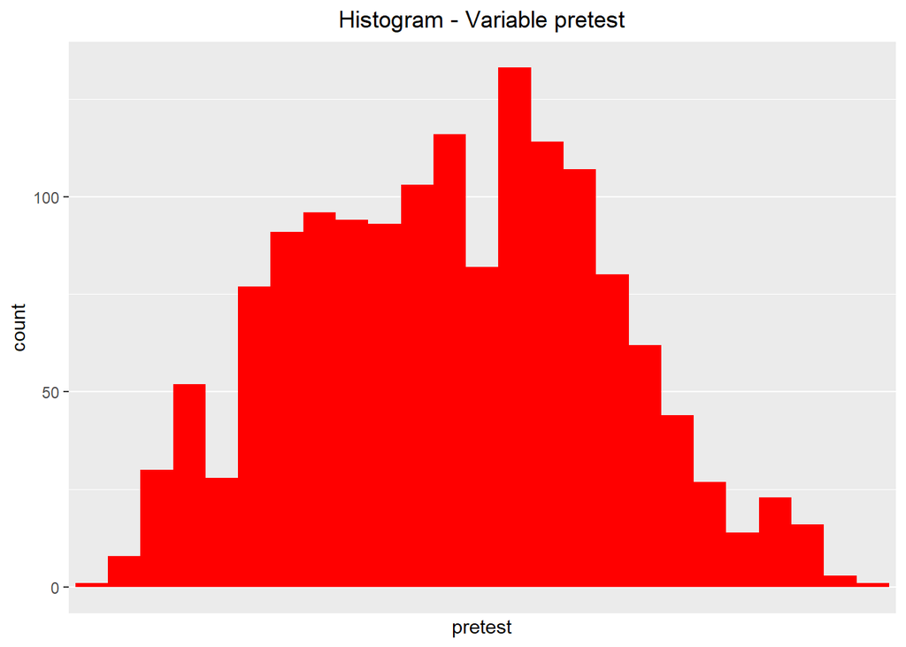

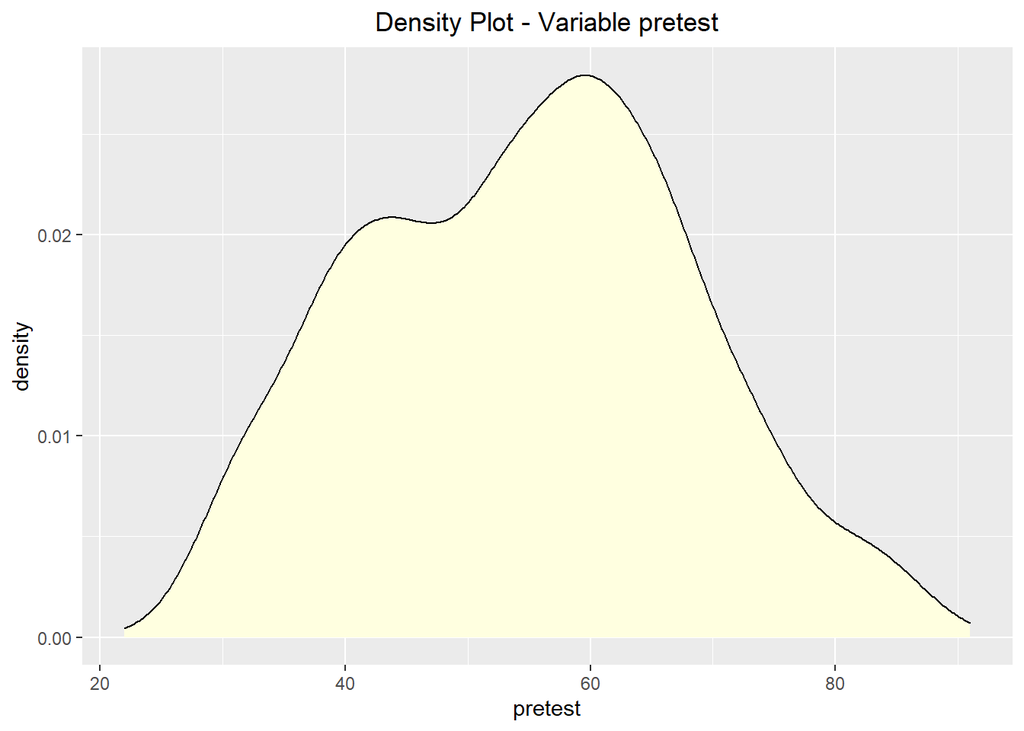

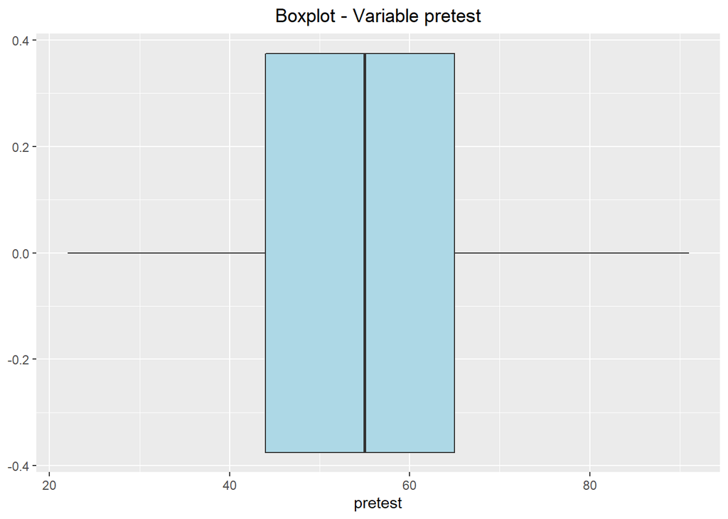

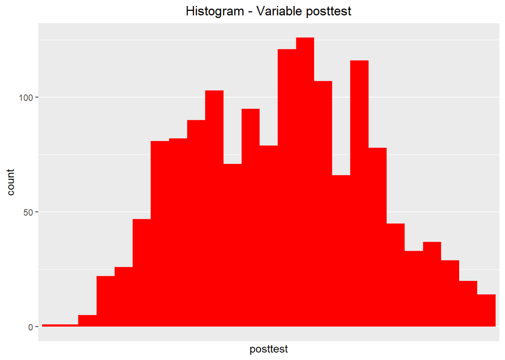

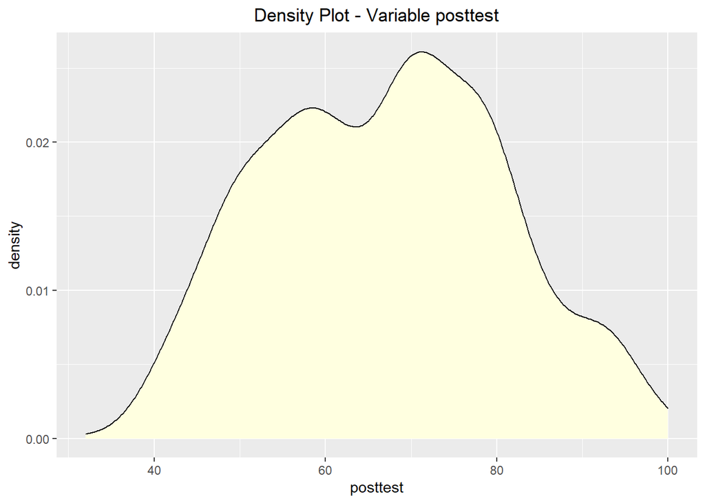

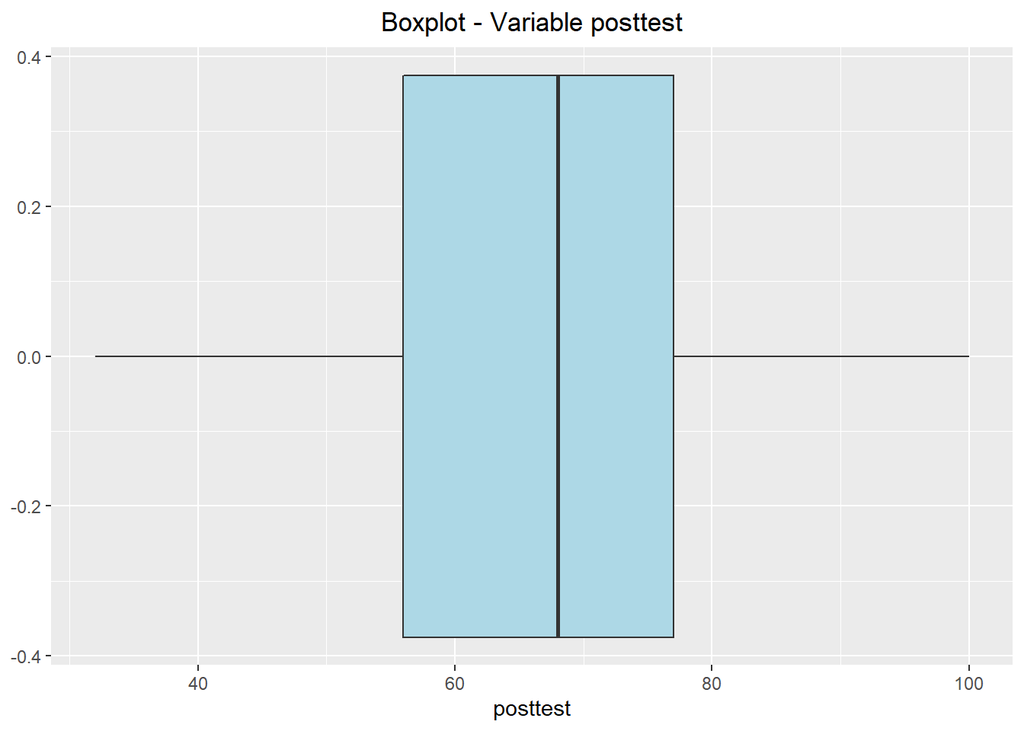